**Instructor copy.** Executed notebook with all results shown, including the "after your attempt" cells. Projector/offline fallback; learners should use the notebook itself.

# f4e · A valley the search can miss, and a check that none is left (advanced steps 15–17)

**In plain words.** With one phase model whose curve has a hump, a search that only walks downhill from the sample's own composition can report "single phase" while a much deeper valley sits far away. In this notebook you watch that happen, keep looking until the true split appears, and then check, piece by piece of the composition range, that no deeper valley is left.

**Learning goals.** After this notebook you can

1. show that a local search on the gap curve from $z=0.15$ misses the valley near $x=0.958$, and that a full scan finds it;
2. keep pricing until the used states reach the coexisting compositions 0.070 and 0.930, and say why one added state was not enough;
3. compute a chord floor on one interval and say why it is a guaranteed floor;
4. run a small branch-and-bound that closes every interval of $[0,1]$, and read its floor, its remaining uncertainty and an unresolved run;
5. (dive deeper) check the answer with a short verifier of your own.

**What you need.** Steps 15–17 of the course, or their cards: which model am I in?, local and global minimum, metastable or unstable, relaxation and underestimator, intervals and halving, prune and incumbent, tolerance, checkable answer. Notebook f4d (column generation) helps but is not required.

| Section | What | Track | Time |
| --- | --- | --- | --- |
| 1 | Local search misses a valley | main | 15 min |
| 2 | Keep pricing | main | 15 min |
| 3 | A floor for one interval | main | 15 min |
| 4 | Branch-and-bound: check that no valley is left | main | 20 min |
| 5 | How short is short enough, and stopping early | dive deeper | 10 min |
| 6 | A checkable answer and your own verifier | dive deeper | 15 min |
| 7 | Exercises | both | 25 min |

**Coming from materials.** The sample at $z=0.15$ is a supersaturated solid solution: metastable. A real alloy may stay like that for a long time. An equilibrium calculation must still find the lower split, and this notebook shows how a computer can miss it and how it can make sure it did not.

**Coming from operations research.** The pricing problem of column generation is now nonconvex. A local pricer can stop the method too early; a spatial branch-and-bound with a secant underestimator turns "no negative reduced cost found" into "none below $-\varepsilon$ exists", in floating point.

**How to work.** Run the cells from top to bottom. In each "Your turn" cell, replace `None` with your value and run it: `check` says whether you match, without showing the answer. Cells marked *After your attempt* hold worked solutions.

```python
# Setup: run this cell first. Locally it finds the course folder; in Colab it
# downloads the tested course release and the locked package versions.
# In Colab, the first run then restarts the session on purpose and Colab reports
# a crash: that is expected. Run this cell again, then the rest of the notebook.
RELEASE = "main"
import os, pathlib, subprocess, sys, time
ROOT = next((p for p in (pathlib.Path.cwd(), *pathlib.Path.cwd().parents)
             if (p / "pyproject.toml").is_file() and (p / "course").is_dir()), None)
if ROOT is None and "google.colab" in sys.modules:
    ROOT = pathlib.Path("/content/CalphadIntro")
    if not ROOT.is_dir():
        clone = ["git", "clone", "-q", "--depth", "1", "--branch", RELEASE,
                 "https://github.com/ukerzel/CalphadIntro.git", str(ROOT)]
        git = dict(os.environ, GIT_TERMINAL_PROMPT="0")
        if subprocess.run(clone, env=git, capture_output=True).returncode:
            raise SystemExit(f"Could not download course release {RELEASE}: check the internet "
                             "connection and run this cell again.")
    if not (ROOT / ".colab-ready").exists():
        if subprocess.run([sys.executable, "-m", "pip", "install", "-q", "-r",
                           str(ROOT / "notebooks" / "requirements-colab.txt")]).returncode:
            raise SystemExit("Installing the course packages failed; run this cell again.")
        (ROOT / ".colab-ready").touch()
        # Colab has already loaded its own numpy; a fresh session is needed to use the installed versions.
        print("Installed the course's package versions. Colab now restarts this session and"
              " reports a crash; that is expected. When it has reconnected, run this cell again"
              " (it will not install twice), then the rest of the notebook.", flush=True)
        time.sleep(3)
        os.kill(os.getpid(), 9)
if ROOT is None:
    raise SystemExit("Open this notebook from the course folder (poetry run jupyter lab) or in Colab.")
os.chdir(ROOT)
sys.path.insert(0, str(ROOT))
from notebooks.helpers import check, confirm, database, show_versions
show_versions(RELEASE)
```

```
Course release main · Python 3.12.14
  numpy       2.5.3
  scipy       1.18.1
  matplotlib  3.11.2
  xarray      2026.7.0
  pycalphad   0.11.2
```

```
True
```

## 0. Numbers you may change, and the tools

Leave these numbers as they are for the first run: the "Your turn" checks expect them. Later, change one at a time and rerun everything below it.

- `T`: the temperature in K (the regular solution of step 03 part B at 800 K);
- `z`: the overall B atom fraction of the sample;
- `EPS`: the tolerance $\varepsilon$ of branch-and-bound, in J/mol atoms;
- `STARTS`: where the local searches of section 1 begin.

```python
T = 800.0                                 # K
z = 0.15                                  # overall B atom fraction of the sample
EPS = 1.0                                 # J/mol atoms: dips shallower than this are not chased
STARTS = [0.05, 0.15, 0.3, 0.5, 0.7, 0.9]  # starts of the local searches
```

Two course modules: `day3_core`, the small library that produced every number on the advanced steps of the website, and `binary_family`, which holds the regular solution itself and its exact coexisting compositions. `alpha.g(x)` is the molar Gibbs energy of the one phase model, ALPHA, in J per mole of atoms; `alpha.slope(x)` is its slope and `alpha.curvature(x)` how strongly it bends.

```python
import numpy as np
import matplotlib.pyplot as plt
from course.self_study import day3_core as d
from course.foundations import binary_family as bf

ALPHA_C, LINE_C, DIP_C = "#2445c4", "#8f6400", "#cf4418"   # the website's colours
models = d.regular_models(T)       # {'ALPHA': model}: step 02's ALPHA plus Omega x(1 - x)
alpha = models["ALPHA"]
```

## 1. Local search misses a valley (main track, 15 min)

Start where a careful program would: with the single uniform state at $z=0.15$ and the tangent there. The tangent's slope is the curve's slope at 0.15; it touches the curve at $g(0.15)$.

```python
d_mu_t = float(alpha.slope(z))            # slope of the tangent at z
g_z = float(alpha.g(z))                   # the uniform state's energy
mu_A_t = g_z - d_mu_t * z                 # the tangent's height at x = 0
confirm(d_mu_t, 14462.127620, "Tangent slope at 0.15", tol=1e-4)
print(f"g(0.15) = {g_z:.1f}   mu_A = {mu_A_t:.1f}   d_mu = {d_mu_t:.1f}   (J/mol)")
```

```
✓ Tangent slope at 0.15 reproduces the lesson value.
g(0.15) = -5461.7   mu_A = -7631.0   d_mu = 14462.1   (J/mol)
```

Is the uniform state at 0.15 stable against small changes? The curvature says how the curve bends: positive means it bends up.

```python
print(f"curvature at 0.15: {float(alpha.curvature(z)):.0f} J/mol atoms")
print("binodal and spinodal:", bf.regular_binodal(T))
```

```
curvature at 0.15: 12169 J/mol atoms
binodal and spinodal: {'status': 'two_compositions', 'compositions': [0.07009052443068386, 0.9299094755693161], 'spinodal': [0.2106731951581396, 0.7893268048418605]}
```

The gap curve is $g(x)$ minus the tangent. At 0.15 it is zero and it rises on both sides. Now let the computer search for states below the line by walking downhill on the gap curve, from several starts. `d.local_descent` returns the compositions it visits; it is the computer's search, not what atoms do.

**Predict first:** where does the search from 0.15 end? And from 0.5?

```python
for start in STARTS:
    path = d.local_descent(alpha, mu_A_t, d_mu_t, start)
    end = path[-1]
    print(f"start {start:.2f}: ends at {end:.4f}, gap {float(alpha.g(end)) - mu_A_t - d_mu_t * end:9.1f}")
```

```
start 0.05: ends at 0.1500, gap      -0.0
start 0.15: ends at 0.1500, gap      -0.0
start 0.30: ends at 0.9579, gap   -2082.0
start 0.50: ends at 0.9579, gap   -2082.0
start 0.70: ends at 0.9579, gap   -2082.0
start 0.90: ends at 0.9579, gap   -2082.0
```

Starts at or near 0.15 never leave it: the gap curve is flat there and rises on both sides, so "no state below the line" looks true. Starts further right roll into a deep valley. The picture shows why.

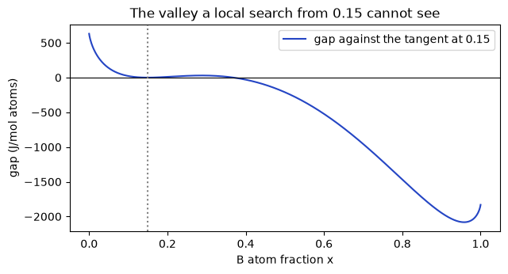

```python
xs = np.linspace(0.0, 1.0, 1001)
gap_t = alpha.g(xs) - (mu_A_t + d_mu_t * xs)
fig, ax = plt.subplots(figsize=(7, 3.4))
ax.plot(xs, gap_t, color=ALPHA_C, label="gap against the tangent at 0.15")
ax.axhline(0, color="black", lw=0.8); ax.axvline(z, color="grey", ls=":")
ax.set(xlabel="B atom fraction x", ylabel="gap (J/mol atoms)", title="The valley a local search from 0.15 cannot see")
ax.legend(); plt.show()
```

A full scan looks everywhere: `d.price_scan` evaluates the gap on 20001 points of $[0,1]$ and refines the best one.

```python
dip = d.price_scan(alpha, mu_A_t, d_mu_t)
print(f"full scan: deepest dip {dip.depth:.1f} J/mol atoms at x = {dip.x:.4f}")
assert dip.depth < -EPS, "expected a valley below the tangent"
```

```
full scan: deepest dip -2082.0 J/mol atoms at x = 0.9579
```

### Your turn: the valley by hand

At $x=0.958$ the curve has $g = 4141.7$ J/mol atoms (printed below). Use the tangent from the first cell of this section to find the gap there. Second: is the uniform sample at 0.15 *stable*, *metastable* or *unstable*?

```python
print(f"g(0.958) = {float(alpha.g(0.958)):.1f} J/mol atoms")
gap_0958 = None     # J/mol atoms, negative
state_015 = None    # one word
check(gap_0958, "f4e_gap_0958")
check(state_015, "f4e_state_015")
```

```
g(0.958) = 4141.7 J/mol atoms
f4e_gap_0958: not attempted yet. Replace None with your value and run the cell again.
f4e_state_015: not attempted yet. Replace None with your value and run the cell again.
```

## 2. Keep pricing (main track, 15 min)

Add the state at the dip and solve the menu again, as in column generation. Here is the surprise: after adding the state near 0.958, the menu has no state left of 0.15, so the only mixture that makes $z=0.15$ is the 0.15 state itself. Many lines pass through that one dot and stay under the 0.958 dot: every one of them is optimal, and the solver returns one of them (here a flat one). Keep pricing anyway.

`d.column_generation` runs the loop; its `line` argument lets round 0 use the tangent we chose by hand (a one-state menu leaves the slope free).

```python
seed = [d.State("ALPHA", z, g_z)]
rounds = d.column_generation(models, seed, z, tol=1e-9, max_iter=12,
                             line=lambda master, k: (mu_A_t, d_mu_t) if k == 0 else (master.mu_A, master.d_mu))
for it in rounds:
    used = ", ".join(f"{s.x:.4f} ({f:.3f})" for s, f in it.master.used())
    label = "chosen by hand" if it.k == 0 else "returned by the solver"
    print(f"round {it.k}: d_mu {it.master.d_mu:9.1f} ({label:22s}) uses {used:30s} deepest dip {it.best.depth:10.4f} at {it.best.x:.4f}")
```

```
round 0: d_mu   14462.1 (chosen by hand        ) uses 0.1500 (1.000)                 deepest dip -2082.0233 at 0.9579
round 1: d_mu      -0.0 (returned by the solver) uses 0.1500 (1.000)                 deepest dip -1593.6093 at 0.0085
round 2: d_mu   11261.8 (returned by the solver) uses 0.1500 (1.000)                 deepest dip  -186.4490 at 0.0595
round 3: d_mu   12029.7 (returned by the solver) uses 0.9579 (0.101), 0.0595 (0.899) deepest dip   -29.5998 at 0.9304
round 4: d_mu   11995.7 (returned by the solver) uses 0.0595 (0.896), 0.9304 (0.104) deepest dip    -3.6942 at 0.0700
round 5: d_mu   12000.0 (returned by the solver) uses 0.9304 (0.093), 0.0700 (0.907) deepest dip    -0.0071 at 0.9299
round 6: d_mu   12000.0 (returned by the solver) uses 0.0700 (0.907), 0.9299 (0.093) deepest dip    -0.0001 at 0.0701
round 7: d_mu   12000.0 (returned by the solver) uses 0.9299 (0.093), 0.0701 (0.907) deepest dip    -0.0000 at 0.9299
```

Round 1 shows the flat line: its gap curve dips about 1594 below near $x\approx0.009$. A line through both the 0.15 and the 0.958 dots would still dip below near 0.068. Neither is wrong; the menu is just too small to fix the line. After four more rounds the used states settle where the regular solution's two phases really are.

```python
two = rounds[1].master.states[1]                  # the state added after round 0 (near 0.958)
slope_two = (two.g - g_z) / (two.x - z)          # the line through both dots
print(f"two-dot line: slope {slope_two:.1f}; its deepest dip:", d.price_scan(alpha, g_z - slope_two * z, slope_two))
final = rounds[-1].master
xs_used = sorted(s.x for s, _ in final.used())
exact = bf.regular_binodal(T)["compositions"]
print(f"used states {xs_used[0]:.4f} and {xs_used[1]:.4f}; exact coexistence {exact[0]:.4f} and {exact[1]:.4f}")
assert all(abs(a - b) < 1e-5 for a, b in zip(xs_used, exact)), "column generation did not reach the binodal"
```

```
two-dot line: slope 11884.9; its deepest dip: Dip(phase='ALPHA', x=0.06827203088533061, depth=-132.7169292738779)
used states 0.0701 and 0.9299; exact coexistence 0.0701 and 0.9299
```

### Your turn: the B-rich phase

What is the composition of the B-rich phase at equilibrium? Is it the same as the composition of the first dip, 0.958?

```python
x_rich = None   # B atom fraction
check(x_rich, "f4e_x_rich")
```

```
f4e_x_rich: not attempted yet. Replace None with your value and run the cell again.
```

## 3. A floor for one interval (main track, 15 min)

Column generation stopped because its last scan found nothing deeper than about 0.0001. A scan is a list of points: it cannot prove that no valley hides between them. A *floor* for a whole interval can.

The regular solution's curve is a straight line, plus the ideal mixing term (which bends up), plus the hump $\Omega x(1-x)$ (which bends down). On an interval $[l,u]$, replace the hump by its chord, the straight line through its values at $l$ and $u$. An arch lies above its chord, so the new curve lies on or below the gap curve on the whole interval. And the new curve bends up everywhere, so its lowest point has a formula:

$$s=b-\Delta\mu+\Omega(1-l-u),\qquad x^*=\frac{1}{1+e^{\,s/RT}}\ \text{(clipped to }[l,u]),$$

where $b=12000$ J/mol is the rise of the straight end line. The floor is the new curve's value at $x^*$.

```python
mu_A, d_mu = final.mu_A, final.d_mu               # the converged line
lo, hi = 0.0625, 0.078125                         # one interval near the touching point 0.070
RT = d.R * T
s = alpha.b - d_mu + alpha.w * (1 - lo - hi)
x_star = min(max(1 / (1 + np.exp(s / RT)), lo), hi)
print(f"s = {s:.1f} J/mol,  x* = {x_star:.5f}")
```

```
s = 17187.5 J/mol,  x* = 0.07018
```

The new curve at $x^*$: the straight part, the mixing part, the chord of the hump, minus the line. The cell then compares your by-hand floor with the library's `d.chord_floor`.

```python
chord = alpha.w * (lo * (1 - lo) + (1 - lo - hi) * (x_star - lo))   # the hump's chord at x*
mixing = RT * (x_star * np.log(x_star) + (1 - x_star) * np.log(1 - x_star))
floor_hand = alpha.a + alpha.b * x_star + mixing + chord - (mu_A + d_mu * x_star)
floor_lib, _ = d.chord_floor(alpha, mu_A, d_mu, lo, hi)
print(f"floor by hand {floor_hand:.4f}, library {floor_lib:.4f} J/mol atoms")
assert abs(floor_hand - floor_lib) < 1e-9, "the by-hand floor differs from the library"
```

```
floor by hand -1.2201, library -1.2201 J/mol atoms
```

How loose can the chord be? The hump lies above its chord by at most $\Omega(u-l)^2/4$, at the midpoint. Halving an interval quarters that: the reason branch-and-bound works. The picture shows the gap curve and the floor curve on this interval.

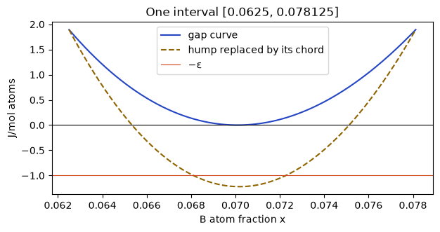

```python
xi = np.linspace(lo, hi, 201)
gap_i = alpha.g(xi) - (mu_A + d_mu * xi)
under = gap_i - alpha.w * xi * (1 - xi) + alpha.w * (lo * (1 - lo) + (1 - lo - hi) * (xi - lo))
fig, ax = plt.subplots(figsize=(7, 3.2))
ax.plot(xi, gap_i, color=ALPHA_C, label="gap curve"); ax.plot(xi, under, color=LINE_C, ls="--", label="hump replaced by its chord")
ax.axhline(-EPS, color=DIP_C, lw=0.8, label="−ε"); ax.axhline(0, color="black", lw=0.8)
ax.set(xlabel="B atom fraction x", ylabel="J/mol atoms", title=f"One interval [{lo}, {hi}]"); ax.legend(); plt.show()
```

### Your turn: one interval

1. Give the floor of $[0.0625, 0.078125]$ to three decimals.
2. Give the largest looseness $\Omega(u-l)^2/4$ on this interval.
3. With $\varepsilon=1$: prune or split?

```python
floor_interval = None   # J/mol atoms
looseness = None        # J/mol atoms
decision = None         # "prune" or "split"
check(floor_interval, "f4e_floor_interval")
check(looseness, "f4e_looseness")
check(decision, "f4e_decision")
```

```
f4e_floor_interval: not attempted yet. Replace None with your value and run the cell again.
f4e_looseness: not attempted yet. Replace None with your value and run the cell again.
f4e_decision: not attempted yet. Replace None with your value and run the cell again.
```

## 4. Branch-and-bound: check that no valley is left (main track, 20 min)

Start with $[0,1]$. For each interval compute its floor. If the floor is at least $-\varepsilon$, nothing in it lies more than $\varepsilon$ below the line: prune it. Otherwise cut it in half and look at both halves. When every interval is pruned, the line lowered by the lowest floor $m$ is a floor for every state:

$$G_{\text{low}}=\mu_A+\Delta\mu\,z+\min(0,m).$$

**Predict first:** where will the intervals have to be short?

```python
proof = d.branch_and_bound(alpha, mu_A, d_mu, eps=EPS)
print(" node  interval                floor      gap at x*   action")
for n in proof.nodes:
    print(f"{n.n:5d}  [{n.lo:.5f}, {n.hi:.5f}]  {n.floor:10.3f}  {n.gap_at_x:10.3f}   {n.action}")
```

```
 node  interval                floor      gap at x*   action
    0  [0.00000, 1.00000]   -4225.433     774.567   split
    1  [0.00000, 0.50000]    -950.498     206.802   split
    2  [0.50000, 1.00000]    -950.498     206.802   split
    3  [0.00000, 0.25000]    -278.204      16.189   split
    4  [0.25000, 0.50000]     315.417     568.406   prune
    5  [0.50000, 0.75000]     315.417     568.406   prune
    6  [0.75000, 1.00000]    -278.204      16.189   split
    7  [0.00000, 0.12500]     -77.418       0.270   split
    8  [0.12500, 0.25000]      64.837      82.408   prune
    9  [0.75000, 0.87500]      64.837      82.408   prune
   10  [0.87500, 1.00000]     -77.418       0.270   split
   11  [0.00000, 0.06250]      -0.426       6.542   prune
   12  [0.06250, 0.12500]     -12.907       2.815   split
   13  [0.87500, 0.93750]     -12.907       2.815   split
   14  [0.93750, 1.00000]      -0.426       6.542   prune
   15  [0.06250, 0.09375]      -4.105       0.313   split
   16  [0.09375, 0.12500]      14.817      14.817   prune
   17  [0.87500, 0.90625]      14.817      14.817   prune
   18  [0.90625, 0.93750]      -4.105       0.313   split
   19  [0.06250, 0.07812]      -1.220       0.000   split
   20  [0.07812, 0.09375]       1.893       1.893   prune
   21  [0.90625, 0.92188]       1.893       1.893   prune
   22  [0.92188, 0.93750]      -1.220       0.000   split
   23  [0.06250, 0.07031]      -0.139       0.064   prune
   24  [0.07031, 0.07812]      -0.099       0.082   prune
   25  [0.92188, 0.92969]      -0.099       0.082   prune
   26  [0.92969, 0.93750]      -0.139       0.064   prune
```

The short intervals collect near 0.070 and 0.930, where the line touches the curve: there the gap is close to zero and any looseness of the chord pushes the floor below $-\varepsilon$. Near the middle the curve lies hundreds of J/mol above the line, and long intervals are pruned at once.

```python
G_up = final.G_up                                   # the best mixture: the ceiling
G_low = mu_A + d_mu * z + min(0.0, proof.m)         # the line lowered by the lowest leaf floor
print(f"{len(proof.nodes)} intervals, {len(proof.leaves)} leaves, status {proof.status}")
print(f"lowest floor m = {proof.m:.3f};  ceiling {G_up:.2f},  floor {G_low:.2f},  remaining {G_up - G_low:.2f} J/mol atoms")
assert proof.status == "proved" and G_up - G_low <= EPS, "branch-and-bound did not close [0, 1] within the tolerance"
```

```
27 intervals, 14 leaves, status proved
lowest floor m = -0.426;  ceiling -5585.11,  floor -5585.53,  remaining 0.43 J/mol atoms
```

### Your turn: read the check

1. What is the floor $G_{\text{low}}$ for the sample?
2. What is the remaining uncertainty, ceiling minus floor?

```python
g_low_answer = None     # J/mol atoms
remaining = None        # J/mol atoms
check(g_low_answer, "f4e_g_low")
check(remaining, "f4e_remaining")
```

```
f4e_g_low: not attempted yet. Replace None with your value and run the cell again.
f4e_remaining: not attempted yet. Replace None with your value and run the cell again.
```

## 5. How short is short enough, and stopping early (dive deeper, 10 min)

The chord is loose by at most $\Omega(u-l)^2/4$, so near a touching point an interval of width about $2\sqrt{\varepsilon/\Omega}\approx0.014$ has a floor near $-\varepsilon$. That width is a scale, not a guarantee. Centre an interval of exactly that width on the touching point 0.070: against the exact common tangent its floor is $-1.000$; against a line only 0.005 J/mol too high it is $-1.005$, so it is split again.

```python
left = bf.regular_binodal(T)["compositions"][0]
d_mu_x = float(alpha.slope(left)); mu_A_x = float(alpha.g(left)) - d_mu_x * left   # the exact common tangent
h = 2 * np.sqrt(EPS / alpha.w)
for raise_by in (0.0, 0.005):
    fl, _ = d.chord_floor(alpha, mu_A_x + raise_by, d_mu_x, left - h / 2, left + h / 2)
    print(f"width {h:.5f}, line raised by {raise_by}: floor {fl:.4f}")
```

```
width 0.01414, line raised by 0.0: floor -1.0000
width 0.01414, line raised by 0.005: floor -1.0050
```

If the line's own gap dips to $-\delta$ (here up to 0.005), pruning is guaranteed only once $\Omega(u-l)^2/4<\varepsilon-\delta$. The computed floor always decides.

Stopping early is allowed, but the answer is then honest about it: after nine intervals, the pieces still waiting have never been examined (no floor at all), and the result is "unresolved", never "stable".

```python
early = d.branch_and_bound(alpha, mu_A, d_mu, eps=EPS, max_nodes=9)
print("status:", early.status)
for n in early.leaves:
    floor_text = "not examined" if n.floor is None else f"floor {n.floor:9.2f}"
    print(f"  [{n.lo:.4f}, {n.hi:.4f}]  {floor_text:>15s}  {n.action}")
```

```
status: unresolved
  [0.0000, 0.0625]     not examined  open
  [0.0625, 0.1250]     not examined  open
  [0.1250, 0.2500]  floor     64.84  prune
  [0.2500, 0.5000]  floor    315.42  prune
  [0.5000, 0.7500]  floor    315.42  prune
  [0.7500, 0.8750]     not examined  open
  [0.8750, 1.0000]     not examined  open
```

## 6. A checkable answer and your own verifier (dive deeper, 15 min)

The result can be checked without trusting the solver. The answer lists the mixture (the ceiling), the final line, every interval and the tolerance.

```python
answer = {"states": [(s.x, f) for s, f in final.used()], "mu_A": mu_A, "d_mu": d_mu,
          "intervals": [(n.lo, n.hi) for n in proof.leaves], "eps": EPS, "z": z,
          "G_up": G_up, "G_low": G_low}
print(f"{len(answer['intervals'])} intervals; mixture", [(round(x, 4), round(f, 3)) for x, f in answer["states"]])
```

```
14 intervals; mixture [(0.9299, 0.093), (0.0701, 0.907)]
```

Here is a separate verifier, about twenty lines. It uses only the formula of section 3, not the library's branch-and-bound. It recomputes the mixture's energy, checks the atom balances, checks that the intervals cover $[0,1]$ without holes, recomputes every interval's floor, and compares ceiling minus floor with the tolerance. This is a floating-point teaching check, not a rigorous proof: rounding is not controlled.

```python
def verify_answer(ans, model, slack=1e-9):
    """Return a list of problems; an empty list means the answer passes."""
    problems, x = [], np.array([s[0] for s in ans["states"]])
    f = np.array([s[1] for s in ans["states"]])
    if f.min() < 0 or abs(f.sum() - 1) > slack or abs(f @ x - ans["z"]) > slack:
        problems.append("the mixture does not keep the atoms")
    if abs(sum(fi * float(model.g(xi)) for xi, fi in zip(x, f)) - ans["G_up"]) > 1e-6:
        problems.append("the ceiling is not the mixture's energy")
    iv = sorted(ans["intervals"])
    if iv[0][0] != 0.0 or iv[-1][1] != 1.0 or any(a[1] != b[0] for a, b in zip(iv, iv[1:])):
        problems.append("the intervals leave a hole in [0, 1]")
    RT_, floors = d.R * model.T, []
    for l, u in iv:
        s_ = model.b - ans["d_mu"] + model.w * (1 - l - u)
        xs_ = min(max(1 / (1 + np.exp(s_ / RT_)), l), u)
        mix = RT_ * float(d.q(xs_))
        floors.append(model.a + model.b * xs_ + mix + model.w * (l * (1 - l) + (1 - l - u) * (xs_ - l)) - ans["mu_A"] - ans["d_mu"] * xs_)
    if min(floors) < -ans["eps"]:
        problems.append("an interval's floor is below −ε")
    g_low = ans["mu_A"] + ans["d_mu"] * ans["z"] + min(0.0, min(floors))
    if abs(g_low - ans["G_low"]) > 1e-6 or ans["G_up"] - g_low > ans["eps"] + slack:
        problems.append("the floor or the remaining uncertainty does not hold")
    return problems
```

The verifier accepts the answer, and rejects it when an interval is removed or the line is raised by 2 J/mol.

```python
print("as computed:", verify_answer(answer, alpha) or "passes")
print("one interval removed:", verify_answer({**answer, "intervals": answer["intervals"][1:]}, alpha))
print("line raised by 2 J/mol:", verify_answer({**answer, "mu_A": mu_A + 2.0}, alpha))
assert not verify_answer(answer, alpha), "the verifier rejects the computed answer"
assert verify_answer({**answer, "mu_A": mu_A + 2.0}, alpha), "the verifier accepts a raised line"
```

```
as computed: passes
one interval removed: ['the intervals leave a hole in [0, 1]']
line raised by 2 J/mol: ["an interval's floor is below −ε"]
```

The library has its own verifier, `d.verify`, written the same way; both agree.

```python
lib_answer = d.Answer([("ALPHA", x, f) for x, f in answer["states"]], mu_A, d_mu, answer["intervals"],
                      EPS, z, EPS, G_up, G_low)
print("library verifier:", d.verify(lib_answer, alpha))
```

```
library verifier: (True, [])
```

## 7. Exercises

**Materials flavour: run, change one number, explain.**

- Raise the temperature above $T_c=\Omega/2R\approx1203$ K, for example to 1250 K. The hump is gone; how many intervals does branch-and-bound need against the tangent at $z$? The cell below runs it. Explain the difference.
- Confine the local searches of section 1 to a window around $z$, as a program that "starts near the answer" would, for example starts between 0.10 and 0.20. Widen the window until a search finds the valley. Which start is the first one that does?

```python
hot = d.regular_models(1250.0)["ALPHA"]
slope_hot = float(hot.slope(z)); mu_hot = float(hot.g(z)) - slope_hot * z
tree = d.branch_and_bound(hot, mu_hot, slope_hot, eps=EPS)
print(f"1250 K: {tree.status} with {len(tree.nodes)} intervals (800 K needed {len(proof.nodes)} against the converged line)")
```

```
1250 K: proved with 15 intervals (800 K needed 27 against the converged line)
```

```python
for window in (0.05, 0.10, 0.15, 0.20):
    starts = np.clip(np.linspace(z - window, z + window, 5), 0.01, 0.99)   # stay inside (0, 1)
    ends = [d.local_descent(alpha, mu_A_t, d_mu_t, float(start))[-1] for start in starts]
    finders = [round(float(st), 3) for st, end in zip(starts, ends) if end > 0.9]   # starts that reach the valley near 0.958
    print(f"starts within ±{window:.2f} of z: furthest end {max(ends):.3f};  starts that find the valley: {finders or 'none'}")
```

```
starts within ±0.05 of z: furthest end 0.150;  starts that find the valley: none
starts within ±0.10 of z: furthest end 0.150;  starts that find the valley: none
starts within ±0.15 of z: furthest end 0.958;  starts that find the valley: [0.3]
starts within ±0.20 of z: furthest end 0.958;  starts that find the valley: [0.35]
```

**Optimisation flavour: complete a function, then one deeper exercise.**

Complete `covers`: given a list of `(l, u)` intervals, return `True` if, once sorted, they start at 0, end at 1 and leave no hole. Test it on the leaves of section 4.

```python
def covers(intervals):
    """True when the sorted intervals cover [0, 1] without a hole."""
    return None   # replace with True or False

check(covers([(n.lo, n.hi) for n in proof.leaves]), "f4e_covers")
```

```
f4e_covers: not attempted yet. Replace None with your value and run the cell again.
```

```python
#@title After your attempt: a solution of covers
def covers_solution(intervals):
    iv = sorted(intervals)
    return iv[0][0] == 0.0 and iv[-1][1] == 1.0 and all(a[1] == b[0] for a, b in zip(iv, iv[1:]))

print(covers_solution([(n.lo, n.hi) for n in proof.leaves]), covers_solution([(0.0, 0.5), (0.6, 1.0)]))
```

```
True False
```

**Deeper exercise (operations research).**

1. Count the intervals of the proof for $\varepsilon$ = 10, 1, 0.1 and 0.01. How does the count grow, and why mostly near the touching points?
2. Write your own loop that takes intervals from a stack (depth-first) instead of a queue (first in, first out). Does the number of intervals change? Does the answer?
3. Replace the full scan in column generation by `d.bb_deepest`, a branch-and-bound that searches for the deepest dip, and run column generation from the 0.15 state. Do the used states reach the compositions of `bf.regular_binodal`?

```python
#@title After your attempt: tolerance, depth-first, and branch-and-bound pricing
from collections import deque
for eps in (10.0, 1.0, 0.1, 0.01):
    print(f"eps {eps:5}: {len(d.branch_and_bound(alpha, mu_A, d_mu, eps=eps, max_nodes=5000).nodes)} intervals")

def count(eps, depth_first):
    todo, seen = deque([(0.0, 1.0)]), 0
    while todo:
        l, u = todo.pop() if depth_first else todo.popleft()
        seen += 1
        if d.chord_floor(alpha, mu_A, d_mu, l, u)[0] < -eps:
            todo.extend([(l, (l + u) / 2), ((l + u) / 2, u)])
    return seen
print("queue:", count(EPS, False), " stack:", count(EPS, True), "intervals (same tree, different order)")

states = list(seed)
for k in range(15):
    master = d.solve_master(states, z)
    line_k = (mu_A_t, d_mu_t) if k == 0 else (master.mu_A, master.d_mu)
    found = d.bb_deepest(alpha, *line_k, tol=0.01, max_nodes=3000).found
    if found.gap_at_x > -1e-4:
        break
    states.append(d.State("ALPHA", found.x_floor, float(alpha.g(found.x_floor))))
print("used states", sorted(round(s.x, 4) for s, _ in master.used()), " binodal", [round(v, 4) for v in exact])
```

```
eps  10.0: 19 intervals
eps   1.0: 27 intervals
eps   0.1: 35 intervals
eps  0.01: 51 intervals
queue: 27  stack: 27 intervals (same tree, different order)
```

```
used states [0.0702, 0.9298]  binodal [0.0701, 0.9299]
```

## Recap

- Against the tangent at 0.15 the gap curve is flat and rises on both sides: a local search there reports "single phase", while a valley 2082 J/mol atoms deep sits near 0.958. The sample is metastable; the calculation must still find the split.
- One added state was not enough: the menu could not fix the line. Pricing on, the used states reach the coexisting compositions 0.070 and 0.930.
- A chord replaces the hump on an interval and gives a guaranteed floor; branch-and-bound prunes intervals whose floor is at least $-\varepsilon$ and splits the rest. When all of $[0,1]$ is pruned, the floor and the ceiling lie within $\varepsilon$: a check for the declared model, in floating point (a teaching check, not a rigorous proof).
- Stopped early, the honest answer is "unresolved".

**On the website:** steps 15 (local search can miss a valley), 16 (check that no valley is left) and 17 (two questions and the joint case). Cards: local and global minimum, metastable or unstable, relaxation and underestimator, prune and incumbent, checkable answer.

**If a cell fails:** rerun the setup cell first; then check that section 0 still has its original numbers.